# FARMR!SK automatic report

Farm: bl4_v3

Published

Last Updated on Tuesday 18 November, 2025 (09:04:46)

**User ID:** trucha **Farm ID:** bl4_v3 **Survey date:** 2024-10-08

# **Risk analysis results**

> *All risk values from Monte Carlo simulations are provided as median (50th percentile) with 95% confidence interval (97.5%–2.5%).*

The annual probability of disease entry is **50%** (35.7-61.2%) for infectious bovine rhinotracheitis (IBR), **62.3%** (60.2-65.1%) for bovine viral diarrhea (BVD) and **0.0479%** (0.0177-0.121%) for tuberculosis (TB).

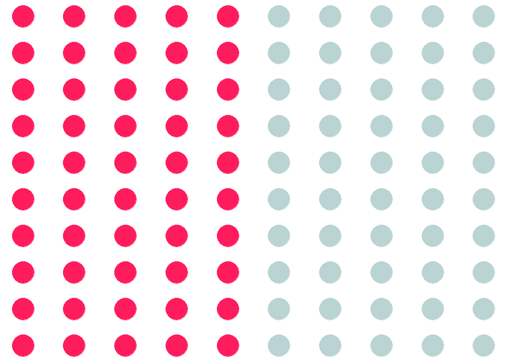

(a) IBR

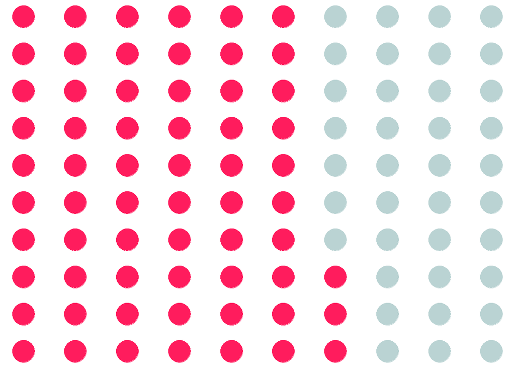

(b) BVD

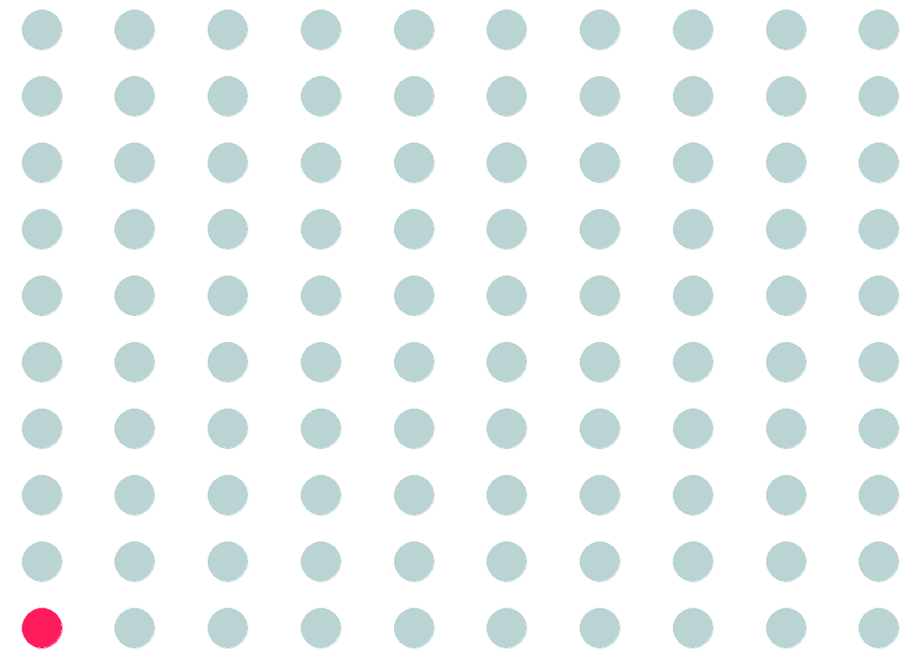

(c) TB

Figure 1.1: Risk of disease entry

The main pathways of disease entry are: **Animals from other origin** and **Animal transport**.

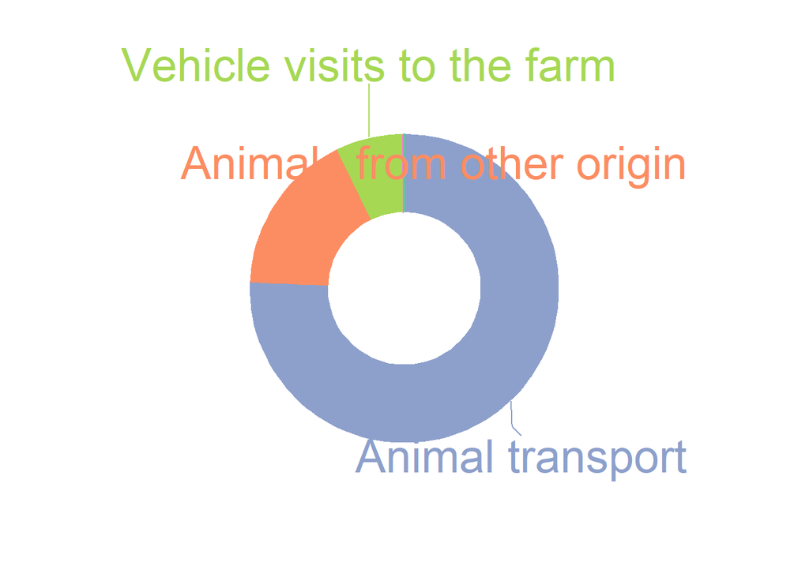

(a) IBR

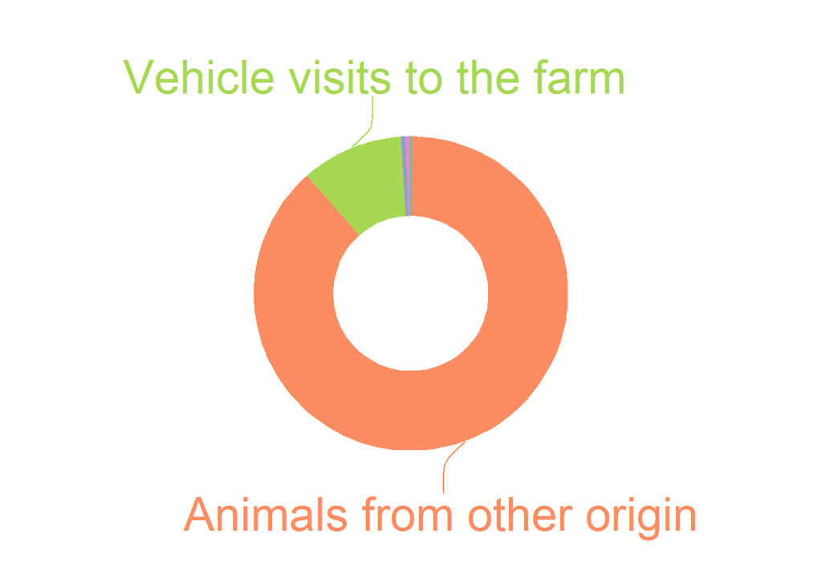

(b) BVD

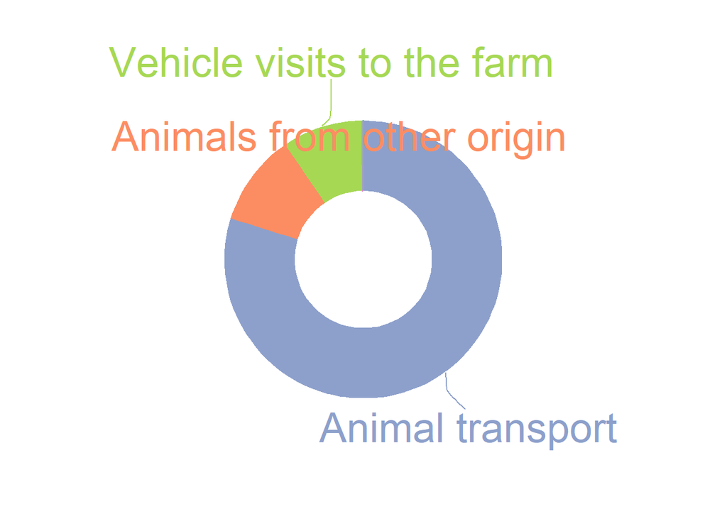

(c) TB

Figure 1.2: Risk of disease entry by pathway

## **Infectious Bovine Rhinotracheitis (IBR)**

### Current risk

Annual risk of IBR entry in the farm: **50%** (35.7-61.2%)

By pathway:

- Animal transport: **39.4%** (24-51.7%)
- Animals from other origin: **8.91%** (7.73-10.5%)
- Vehicle visits to the farm: **3.65%** (1.4-6.77%)
- People visits to the farm: **0.0834%** (0.0172-0.223%)
- Neigbouring farms: **0.00415%** (0.000203-0.0133%)

### Risk reduction of biosecurity measures

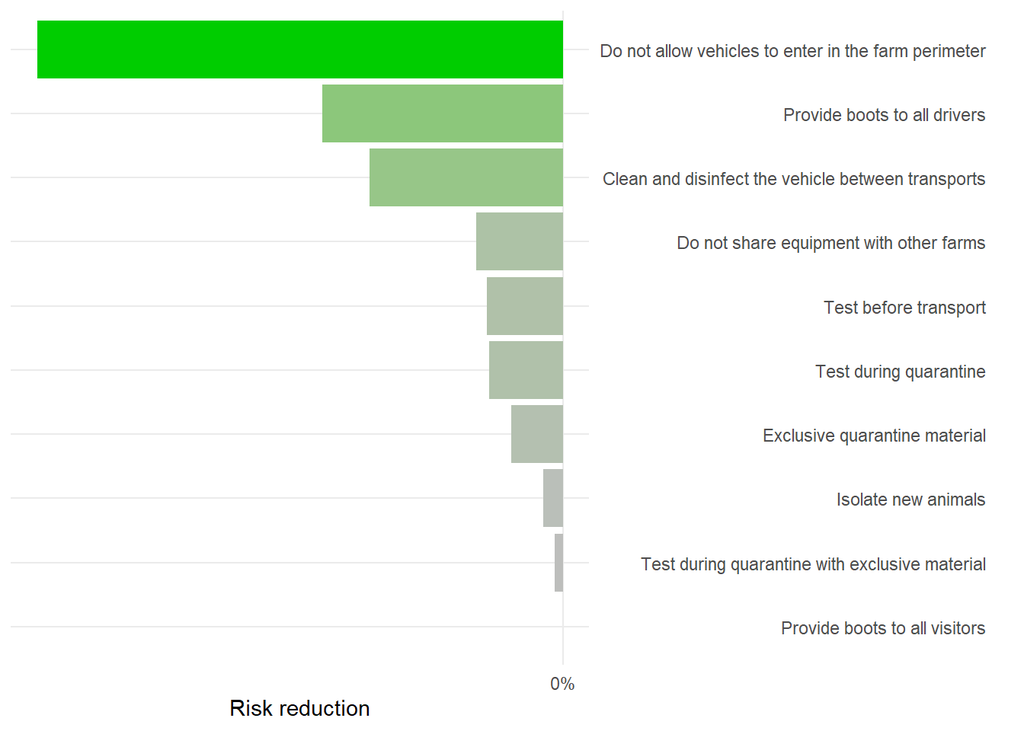

## **Bovine viral diarrhea (BVD)**

### Current risk

Annual risk of BVD entry in the farm: **62.3%** (60.2-65.1%)

By pathway:

- Animals from other origin: **59%** (58.2-59.9%)
- Vehicle visits to the farm: **6.99%** (2.22-13.8%)
- Animal transport: **0.318%** (0.0771-1.27%)
- People visits to the farm: **0.317%** (0.0562-1.05%)
- Neigbouring farms: **1.48e-10%** (3.66e-13-2.35e-09%)

### Risk reduction of biosecurity measures

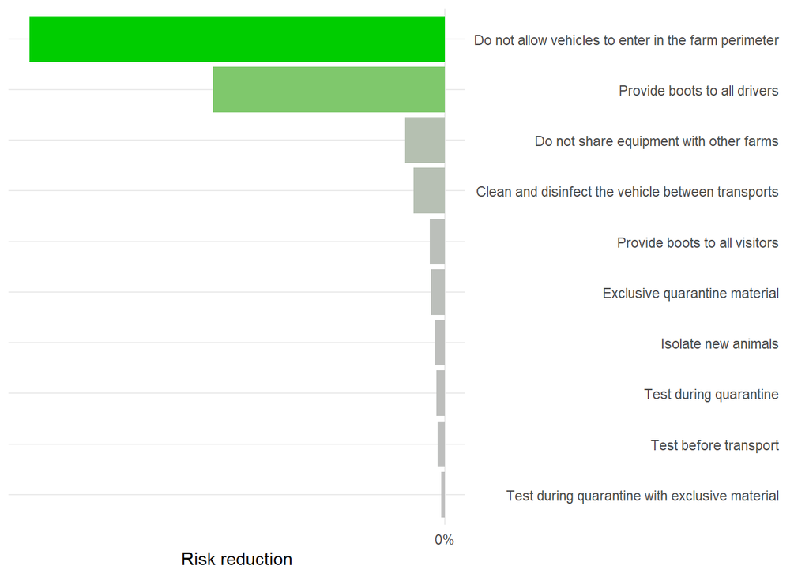

## **Bovine Tuberculosis (TB)**

### Current risk

Annual risk of TB entry in the farm: **0.0479%** (0.0177-0.121%)

By pathway:

- Animal transport: **0.0364%** (0.00829-0.107%)
- Animals from other origin: **0.00485%** (0.00233-0.00951%)
- Vehicle visits to the farm: **0.00423%** (0.000403-0.0198%)
- People visits to the farm: **8.89e-05%** (7e-06-0.000795%)
- Neigbouring farms: **6.14e-07%** (3.54e-10-2.08e-05%)

### Risk reduction of biosecurity measures

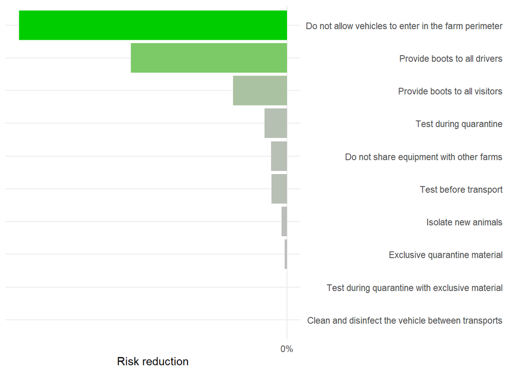

# 🐄 Description of the farm

## Farm information

**Location:** Cataluña, Spain

**Farm type:** Dairy cattle, NA

**Cattle cens:**

- 30 Calves ( <8 m)
- 300 Heifers (8 - 24 m)
- 850 Adult cows (>24 m)
- 0 Bulls

**Other animals in the farm:**

- **Direct contact with cattle:** 20 cats
- **No direct contact with cattle:**

**Neighbours**: 1 cattle farms within a 1-2km radious, no direct contact (IBR: 0.00415%, BVD: 1.48e-10%, TB: 6.14e-07%)

## Farm vehicles

| veh_id | Size | Shared | Cleaning |
| --- | --- | --- | --- |
| Camioncito verde (c) | 8m2 | No | From time to time |
| Camioncito del vecino (b) | 5m2 | Shared with 1 cattle farms | From time to time |

## Visits

### People entering the barn

| Visit | Type | Frequency | Boots | Equipment | Risk |
| --- | --- | --- | --- | --- | --- |
| Veterinari reproducció | External veterinarians | 140 | Never used in other farms | Always used in other farms, always cleaned and disinfected | IBR: 0.0771%, BVD: 0.291%, TB: 7.77e-05% |
| Podòleg | Other animal professionals (e.g. hoof trimmer) | 3 | Always used in other farms, unk cleaned and disinfected | Always used in other farms, unk cleaned and disinfected | IBR: 0.00492%, BVD: 0.0181%, TB: 6.3e-06% |
| Veterinari sanejament | External veterinarians | 1 | Always used in other farms, unk cleaned and disinfected | Always used in other farms, always cleaned and disinfected | IBR: 0.00123%, BVD: 0.00465%, TB: 1.56e-06% |

### Vehicles entering the farm perimeter

| Visit | Type | Frequency | Driver | Risk |
| --- | --- | --- | --- | --- |
| Vedells engreix | Calf transport vehicle | 24 | Contacts farm animals, boots always used in other farms, unk cleaned and disinfected | IBR: 3.34%, BVD: 6.91%, TB: 0.00402% |
| Escorxador vaques | Slaughterhouse vehicle | 100 | No contact with animals | IBR: 0.203%, BVD: 0.0422%, TB: 1.41e-05% |
| Concentrat i gra | Feed vehicle | 150 | - | IBR: 0.0352%, BVD: 0.00691%, TB: 2.72e-06% |

# 🚚 Movements

| mov_id | When | Origin | Animals moved | Shared site | Vehicle used | Risk |
| --- | --- | --- | --- | --- | --- | --- |
| girona_150_todo | ➡️ One-off entry: 2023-06-07 | Other farm/s: Girona | 45 Heifers (8 - 24 m), 105 Adult cows (>24 m) | - | External | IBR: 47.2%, BVD: 55.7%, TB: 0.041% |
| 6_vedelles_vei | ➡️ One-off entry: 2023-11-01 | Other farm/s: Lleida | 6 Calves ( <8 m) | - | Own Camioncito del vecino | IBR: 1.37%, BVD: 8.09%, TB: 0.000453% |

### Health status and tests in origin

| mov_id | Pathogen | Health status in origin | Test in origin |
| --- | --- | --- | --- |
| 6_vedelles_vei | BVD | Unknown | PCR for antigen detection |
|  | IBR |  | ELISA for antibody detection |
|  | TB | T3H (Long-term officially free) | Single intradermal tuberculin |
| girona_150_todo | BVD | Unknown | PCR for antigen detection |
|  | IBR |  | ELISA for antibody detection |
|  | TB | T3H (Long-term officially free) | Single intradermal tuberculin |

### Quarantine

#### Characteristics

*No quarantine*

# 🐗 Wildlife

**Wildlife:** negligible risk

- Outdoors grazing: No outdoors grazing (negligible risk)
- Pasture (trashumance): No pastures

### Farm water points

*No outdoors water points*

### Pasture water points

*No pasture water points*

# Comments

*No survey comments*

# Technical Annex